# Simulações

## Por que usar simulação?

Suponha que temos uma amostra aleatória \(X_1,X_2,\dots,X_n\) de uma distribuição \(X \sim Bin(1,p)\).

Sabemos que um I.C. com coeficiente de confiança \(\gamma\) para \(p\) é encontrado usando a aproximação da Binomial pela Normal, e a expressão para o intervalo é

\[(\bar{X} - z_{(1-\alpha /2)}\sqrt{\frac{\bar{X}(1-\bar{X})}{n}} ; \bar{X} + z_{(1-\alpha /2)}\sqrt{\frac{\bar{X}(1-\bar{X})}{n}})\]

onde \(\alpha = 1-\gamma\)

Mas como podemos ver que esse intervalo de fato vai conter a verdadeira proporção \(p\), em média, \(100\gamma \%\) das vezes? Usando simulação!

## Intervalo de Confiança para proporção

Por exemplo, suponha que temos uma amostra de \(n=30\) e \(p=0.5\). (Perceba que é uma simulação, já que na "vida real" não saberíamos o verdadeiro valor de \(p\).)

Podemos usar o software R para gerar uma amostra com essas características, e fazer um I.C. para \(p\) usando essa amostra.

## Intervalo de Confiança para proporção

O código abaixo gera essa população e calcula um I.C. com \(\gamma = 0.95\)

```r
n=30
p=0.5
gamma = 0.95
alpha = 1-gamma
za = qnorm(1-alpha/2)  ##P(Z <= 1-alpha/2). 1.96 para alpha = 0.05.
x = rbinom(n,1,p)     ##Gera n Binomiais com parâmetros (1,p)
IC = mean(x) + c(-1,1)*za*sqrt(mean(x)*(1-mean(x)))/sqrt(n)
names(IC) = c("Limite Inferior","Limite Superior")
IC
```

```
## Limite Inferior Limite Superior
##       0.2560114       0.6106552
```

## Intervalo de Confiança para proporção

Mas pode acontecer que esse intervalo não contenha a verdadeira proporção!

O que podemos fazer então é repetir a construção desse intervalo para várias amostras diferentes e ver em quantas das repetições o intervalo encontrado realmente contenha \(p\).

E, fazendo isso, temos uma estimativa para a real cobertura do intervalo, que seria \[\frac{\textrm{# Intervalos que contém p}}{\textrm{# Total de intervalos}}\]

## Intervalo de Confiança para proporção

Calculando IC's para diferentes amostras:

```r
m=1000  #Número de repetições/IC's gerados
IC = matrix(0,m,2) #Cada linha é um IC, cada coluna um limite
colnames(IC) = c("lower","upper")
for(i in 1:m){  #Gerando os ICs
  x = rbinom(n,1,p)
  IC[i,] = mean(x)+c(-1,1)*za*sqrt(mean(x)*(1-mean(x)))/sqrt(n)
}
y = sum(as.numeric((IC[,1]<p & p<IC[,2])))
names(y) = "Quantidade de Intervalos que contém p"
gamma = y/m
names(gamma) = "Estimativa para a cobertura do intervalo"
```

## Intervalo de Confiança para proporção

O código acima gerou 1000 intervalos de confiança com \(\gamma = 0.95\).

A variável `y` conta quantos dos intervalos gerados contém \(p\), que nesse caso é 0.5. Temos então:

```r
y
```

```
## Quantidade de Intervalos que contém p
##                                   953
```

## Intervalo de Confiança para proporção

E a variável `gamma` é uma estimativa para a cobertura do intervalo

\[(\bar{X} - z_{(1-\alpha /2)}\sqrt{\frac{\bar{X}(1-\bar{X})}{n}} ; \bar{X} + z_{(1-\alpha /2)}\sqrt{\frac{\bar{X}(1-\bar{X})}{n}}).\]

Note que o esperado é que esse intervalo cubra a verdadeira proporção \(95 \%\) das vezes. E, nesse caso, temos:

```r
gamma
```

```
## Estimativa para a cobertura do intervalo
##                                    0.953
```

## Largura mínima I.C. para variância

Considere \(X_1,X_2, \dots, X_n\) uma a.a. de uma distribuição \(X \sim N(\mu,\sigma^2)\). Sabemos que

\[Q = \frac{(n-1)S^2}{\sigma ^2} \sim \chi_{(n-1)}^2\]

E que um I.C. \(100\gamma \%\) para variância é:

\[(\frac{(n-1)S^2}{q_2} , \frac{(n-1)S^2}{q_1})\]

onde \(q_1\) e \(q_2\) são tais que

\[\int_{q_1}^{q_2} f_Q(x) dx = \gamma\]

## Largura mínima I.C. para variância

Vamos encontrar a largura mínima para quando \(\gamma =0.95\) e \(n=51\).

Note que de \(\int_{q_1}^{q_2} f_Q(x) dx = 0.95\), precisamos que

\[P(Q<q_1)+P(Q>q_2) = 0.05\]

Seja \(P(Q<q_1) = \alpha\) e \(P(Q>q_2) = \beta\). Então, temos a relação \(\beta = 0.05-\alpha\). Por exemplo, se \(\alpha = 0.02\), então \(\beta = 0.03\).

O código abaixo começa considerando diferentes valores para \(\alpha\) e encontra \(q_1\) e \(q_2\) para cada um desses valores.

## Largura mínima I.C. para variância

```r
alpha = seq(from = 0.001, to = 0.05, by = 0.00001)
beta = 0.05-alpha
n=51

q_1 = qchisq(alpha,n-1)
q_2 = qchisq(1-beta,n-1)

quantis = data.frame(q_1,q_2)
colnames(quantis) = c("q_1","q_2")
head(quantis)
```

```
##        q_1      q_2
## 1 24.67391 67.62411
## 2 24.69213 67.62531
## 3 24.71021 67.62652
## 4 24.72813 67.62772
## 5 24.74590 67.62892
## 6 24.76352 67.63013
```

## Largura mínima I.C. para variância

Note que se definirmos `ProbIC` como a integral que discutimos acima, para cada um desses \(q_1\) e \(q_2\), o resultado seria sempre \(0.95\).

```r
ProbIC = pchisq(q_2,n-1)-pchisq(q_1,n-1)
y=mean(ProbIC<0.95+0.001 & ProbIC>0.95-0.001)
y  ##Se y=1, então todos elementos de ProbIC são 0.95
```

```
## [1] 1
```

Note que como \(y=1\), todos elementos do vetor `ProbIC` são 0.95 (Consideramos um erro de 0.001, para aproximações.)

## Largura mínima I.C. para variância

Vamos agora, dada uma amostra da normal, encontrar a largura de I.C. para cada valores de \(\alpha\).

## Largura mínima I.C. para variância

```r
x = rnorm(n,0,50)
S2 = var(x)
largura = (n-1)*S2*(1/q_1-1/q_2)
```

Agora, temos um vetor com a largura do I.C. para cada valores de \(q_1\) e \(q_2\).

O gráfico a seguir considera a largura em função de \(q_1\)

## Largura mínima I.C. para variância

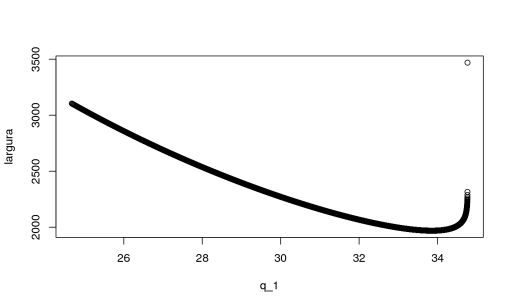

## Largura mínima I.C. para variância

Note pelo gráfico que a largura do I.C. tem um ponto mínimo. Podemos encontrar esse ponto fazendo:

```r
idx = which.min(largura)
largura[idx]
```

```
## [1] 1968.936
```

E os valores de \(q_1\) e \(q_2\) que levam a essa largura mínima são

```r
qs = c(q_1[idx],q_2[idx])
names(qs) = c("q_1","q_2")
qs
```

```
##      q_1      q_2
## 33.85513 75.69396
```

## Largura mínima I.C. para variância

Na página \(383\) do livro "Introduction to The Theory of Statistics - Mood, Alexander McFarlane", foi derivada uma relação para que a largura do intervalo para variância seja mínima. Essa relação é:

\[\begin{array} qq_1^2f_Q(q_1) = q_2^2f_Q(q_2) \\ \int_{q_1}^{q_2}f_Q(x) dx = \gamma \end{array}\]

## Largura mínima I.C. para variância

E, no nosso exemplo, temos

```r
v1 = qs[1]*qs[1]*dchisq(qs[1],n-1)
v2 = qs[2]*qs[2]*dchisq(qs[2],n-1)
v = round(v1/v2,3)
names(v)=NULL
v
```

```
## [1] 1
```

Ou seja, nosso resultado condiz com a relação citada.

## Comentários

Se quiser calcular os resultados aqui apresentados para outros tamanhos amostrais ou outros coeficientes de confiança, basta usar o mesmo código, mudando os valores de \(n\) e \(gamma\).